# DS202_lab3

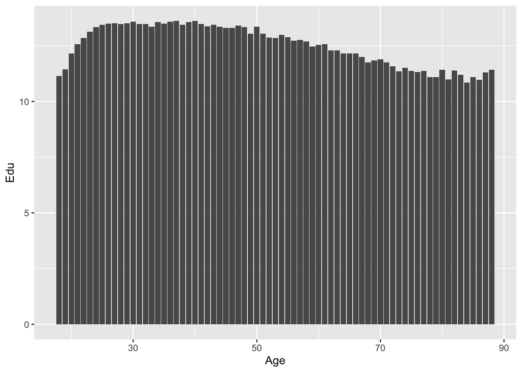

```r
ggplot(data=dat, mapping=aes(x=Age, y=Edu)) +
  stat_summary(fun.data=mean_sdl, geom="bar")
```

```r
aggregate(Age ~ Edu , dat, mean)
```

```
##    Edu      Age
## 1    0 62.53595
## 2    1 60.87234
## 3    2 58.32432
## 4    3 61.28685
## 5    4 61.83923
## 6    5 61.03562
## 7    6 56.81807
## 8    7 58.94798
## 9    8 60.59021
## 10   9 49.16303
## 11  10 48.35907
## 12  11 42.86477
## 13  12 45.07734
## 14  13 41.64291
## 15  14 43.13369
## 16  15 41.31615
## 17  16 44.03819
## 18  17 43.54918
## 19  18 46.69877
## 20  19 46.37555
## 21  20 48.64286
```

## This chart shows the comparison between years of education and whether or not the responder has a gym membership. On average, having a gym membership shows that you have more years of education as compared to any of the other categories. While don’t know shows you have the lowest by nearly 3 whole years. This shows that people with a higher education tend to care more about their helath.

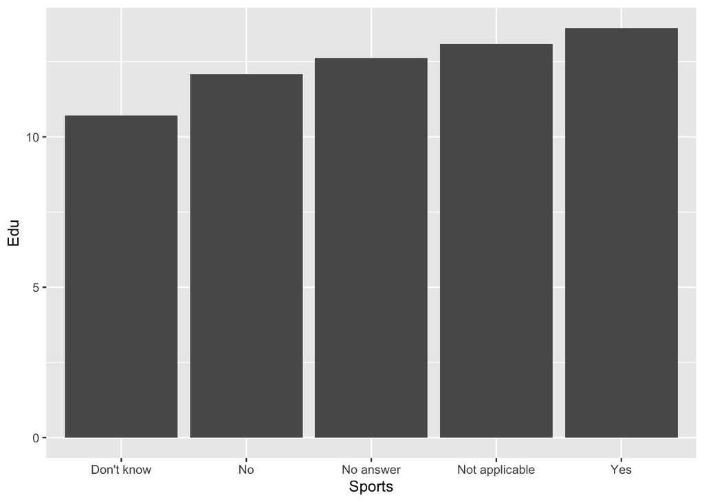

```r
ggplot(data=dat, mapping=aes(x=Sports, y=Edu)) +
  stat_summary(fun.data=mean_sdl, geom="bar")
```

```r
aggregate(Edu ~ Sports , dat, mean)
```

```
##           Sports      Edu
## 1     Don't know 10.71429
## 2             No 12.08867
## 3      No answer 12.61929
## 4 Not applicable 13.09970
## 5            Yes 13.61699
```